# P1: Testanto um Fenômeno de Percepção

Pedro Barbosa de Oliveira Filho

14 de fevereiro de 2017

## Estatística: A Ciência das Escolhas

Carregando pacotes utilizados

```r
library("knitr")
library("e1071")
```

Carregando os dados do teste Stroop:

```r
stroopdata <- read.csv(file = "stroopdata.csv", header = TRUE)
```

#### 1. Qual é a nossa variável independente? Qual é a nossa variável dependente?

*Resposta*: A variável independente é a condição (conguente ou incongruente) na qual o teste Stroop é aplicado. Já a variável dependente é o tempo que cada indivíduo leva para falar os nomes em uma lista de cores e de tamanhos iguais.

#### 2. Qual seria um conjunto apropriado de hipóteses para essa tarefa? Que tipo de teste estatístico você espera executar? Justifique suas escolhas.

*Resposta*: O conjunto apropriado de hipóteses para essa tarefa seria:

$H_{0}:\mu_{conguente}=\mu_{inconguente}$

$H_{1}:\mu_{conguente}\not=\mu_{inconguente}$

onde $H_{0}$ corresponde à hipótese nula, $H_{1}$ corresponde à hipótese alternativa e $\mu$ corresponde à média de tempo dos testes.

Especificamente, estamos interessados em decidir se a média de tempo para realização dos testes Stroop congruente e incongruentes são ou não iguais (ou se existe ou não difernça entre as médias de tempo de realização dos testes). Nota-se que a hipótese alternativa $H_{1}$ é bilateral, desta forma a hipótese nula $H_{0}$ deve ser rejeitada caso haja difereça (positiva ou negativa) significativa entre as médias.

Espera-se executar o **teste t de Student** devido ao fato de estarmos lidando com uma amostra de tamanho $n<30$ e não conhecemos os valores verdadeiros da média e desvio padão da população de onde foi coletada a amostra. Nota-se que cada participante realiza, primeiramente, um teste Stroop congruente e em seguida realiza um teste Stroop congruente. Tal circunstância é característica de *amostras pareadas*.

#### 3. Reporte alguma estatística descritiva em relação a esse conjunto de dados. Inclua, pelo menos, uma medida de tendência central de pelo menos uma medida de variabilidade.

*Resposta*:

Seguem abaixo algumas medidas de tendência central:

```r
sumario <- sapply(stroopdata, summary)
MTC     <- rbind(sumario)
MTC     <- round(MTC, 2)

knitr::kable(x = MTC, align = 'c')
```

|  | Congruent | Incongruent |
| --- | --- | --- |
| Min. | 8.63 | 15.69 |
| 1st Qu. | 11.90 | 18.72 |
| Median | 14.36 | 21.02 |
| Mean | 14.05 | 22.02 |
| 3rd Qu. | 16.20 | 24.05 |
| Max. | 22.33 | 35.26 |

Seguem abaixo algumas medidas de variabilidade:

```r
Amplitude <- diff(sapply(stroopdata, range))
Var       <- sapply(stroopdata, var)
StaDev    <- sapply(stroopdata, sd)
CV        <- StaDev/sapply(stroopdata, mean)
Kurtosis  <- sapply(stroopdata, kurtosis)
Skewness  <- sapply(stroopdata, skewness)
MD        <- rbind(Amplitude, Var, StaDev, CV, Kurtosis, Skewness)
MD        <- round(MD, 2)

knitr::kable(x = MD, align = 'c')
```

|  | Congruent | Incongruent |
| --- | --- | --- |
|  | 13.70 | 19.57 |
| Var | 12.67 | 23.01 |
| StaDev | 3.56 | 4.80 |
| CV | 0.25 | 0.22 |
| Kurtosis | -0.62 | 1.52 |
| Skewness | 0.37 | 1.36 |

#### 4. Forneça uma ou duas visualizações que mostre a distribuição da amostra de dados. Escreva uma ou duas sentenças sobre o que você observou do gráfico ou gráficos.

*Resposta*: As duas formas de vizualização escolhidas das distribuições dos dados de tempo, coletados para o teste Stroop congruente e incongruente, foram o histograma e o boxplot, respectivamente.

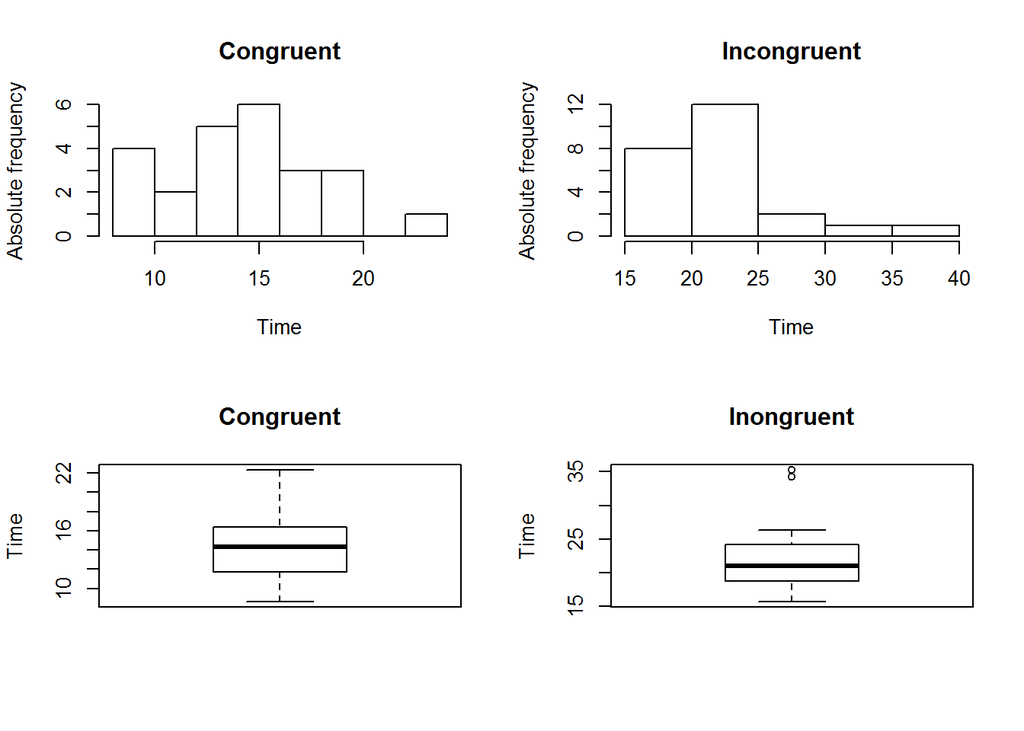

```r
par(mfrow = c(2,2))

HistCongruent   <- hist(stroopdata$Congruent,
                        main = "Congruent",
                        xlab = "Time",
                        ylab = "Absolute frequency")

HistIncongruent <- hist(stroopdata$Incongruent,
                        main = "Incongruent",
                        xlab = "Time",
                        ylab = "Absolute frequency")

BPCongruent     <- boxplot(x = stroopdata$Congruent,
                           main = "Congruent",
                           ylab = "Time")

BPInongruent    <- boxplot(x = stroopdata$Incongruent,
                           main = "Inongruent",
                           ylab = "Time")
```

Nota-se que a os dados do teste Stroop congruente aparentam estar normalmete distribuidos ao redor do valor médio. O box-plot não apresenta valores aberrantes (outliers) e ajuda a identificar uma leve assimetria a direita.

Já os dados do teste Stroop incongruente aparentam estar distantes de um comportamento normal. Os dados encontram-se concentrados à esuqerda da distribuição, caracterizando uma acentuada assimetia a direita. O box-plot confirma a assimetria e ainda identifica a presença de outliers.

#### 5. Agora desempenhe o teste estatístico e reporte seus resultados. Qual seu nível de confiança e o valor estatístico crítico? Você rejeitou a hipótese nula ou falhou ao tentar rejeitá-la? Encontre uma conclusão em relação ao experimento da tarefa. Os resultados estão de acordo com suas expectativas?

Foram realizados dois testes de hipóteses. O primeiro teste é um teste inferência para as variâncias. Para efeito deste deste, assume-se que os dados dos dois testes Stroop seguem uma distribuição normal. O objetivo do teste das variâncias é avaliar a hipótese de igualdade entre as mesmas.

O segundo teste é um teste t de Studente para inferência na difernça entre médias de duas distribuições normais. Novamente assume-se que os dados dos testes Stroop seguem uma distribuição normal.

```r
teste.var <- var.test(x = stroopdata$Congruent,
                      y = stroopdata$Incongruent,
                      ratio = 1,
                      alternative = "two.sided",
                      conf.level = 0.95)
print(teste.var)
```

```
##
##  F test to compare two variances
##
## data:  stroopdata$Congruent and stroopdata$Incongruent
## F = 0.55055, num df = 23, denom df = 23, p-value = 0.1599
## alternative hypothesis: true ratio of variances is not equal to 1
## 95 percent confidence interval:
##  0.2381624 1.2726643
## sample estimates:
## ratio of variances
##          0.5505459
```

```r
teste.t <- t.test(x = stroopdata$Congruent,
                  y = stroopdata$Incongruent,
                  alternative = "two.sided",
                  var.equal = TRUE,
                  conf.level = 0.95,
                  paired = TRUE)
print(teste.t)
```

```
##
##  Paired t-test
##
## data:  stroopdata$Congruent and stroopdata$Incongruent
## t = -8.0207, df = 23, p-value = 4.103e-08
## alternative hypothesis: true difference in means is not equal to 0
## 95 percent confidence interval:
##  -10.019028  -5.910555
## sample estimates:
## mean of the differences
##               -7.964792
```

```r
t_critico <- qt(p = (0.05/2), df = 23, lower.tail = TRUE)
print(t_critico)
```

```
## [1] -2.068658
```

O teste para as variâncias foi realizado considerando um nível de confiânça de 95%. O teste para as variâncias falhou em rejeitar a hipótese nula de igualdade, devido à obtenção de um p-valor superior ao nível de significância de 5%.. O teste também calculou o intervalo de confiânça para a razão entre as variâncias. Devido ao fato do valor unitário estar contido no intervalo de confiânça, o teste falhou em rejeitar a hipótese nula de igualdade entre as variâncias.

O teste para as variâncias é importante para determinar a suposição de igualdade entre as variâncias no teste t de Student. O teste t foi realizado considerando um nível de confiânça de 95%, amostras pareadas e considerando a hipótese de igualdade entre as variâncias (resultado do teste para as variâncias). O teste t rejeitou a hipótese de igualdade entre as médias do teste Stroop congruente e incongruente, devido à obtenção de um p-valor inferior ao nível de significância de 5%. O teste t também obteve o intervalo de confiânça para a difernça entre as médias dos testes de Stroop. Devido ao fato do valor zero não estar contido no intervalo de confiânça, o teste rejeitou a hipótese nula de igualdade entre as médias. O valor de t crítico também foi calculado. Avaliando o t crítico, podemos rejeitar a hipótese nula de igualdade entre as médias de tempo dos teste já que $t_{0}$ (-8.0207069) é menor do que $t_{crítico}$ (-2.0686576)

#### 6. Opcional: O que você acha que é responsável pelo efeito observado? Consegue pensar em uma alternativa ou tarefa similar que resultaria em um efeito parecido?

Acredito que o efeito observado é resultado da diferença de dificuldade entres os testes Stroop congruente e incongruente. O teste incongruente exige um nível mais de concentração, logo os dados coletados apresentam maiores valores médio de tempo de resposta.

#### Referências

Montgomery, D. & Runger, G. (2003), “Estatística Aplicada e Probabilidade para Engenheiros”, 4a. edição, LTC, Rio de Janeiro.